# 류경민

### 연습문제 3문제를 풀면서 감각을 익혀보자!!

## 포함된 라이브러리 입니다.

```r
library(readxl)
library(stringr)
library(KoNLP)
```

```r
library(reshape2)
library(plotly)
library(extrafont)
windowsFonts()
```

```
## $serif
## [1] "TT Times New Roman"
##
## $sans
## [1] "TT Arial"
##
## $mono
## [1] "TT Courier New"
```

```r
windowsFonts(malgun = "맑은 고딕")
library(RColorBrewer)
theme_update(text = element_text(family = "malgun"))
```

## 3-3 취직하기 어렵네요 : 실업률 그래프 입니다.

```r
data1 <- read.csv("data/2000-2013년 연령별실업율_15-19세.csv",header=T)
data2 <- read.csv("data/2000-2013년 연령별실업율_20-29세.csv",header=T)
data3 <- read.csv("data/2000-2013년 연령별실업율_30-39세.csv",header=T)
data4 <- read.csv("data/2000-2013년 연령별실업율_40-49세.csv",header=T)
data5 <- read.csv("data/2000-2013년 연령별실업율_50-59세.csv",header=T)
data6 <- read.csv("data/2000-2013년 연령별실업율_60세이상.csv",header=T)
data1
```

```
##      월 X2000년 X2001년 X2002년 X2003년 X2004년 X2005년 X2006년 X2007년
## 1     1    19.7    16.4    14.8    13.4    16.9    19.8    12.4     9.3
## 2     2    15.1    18.8    13.3    12.2    14.8    13.6    11.2    10.3
## 3     3    15.7    19.5    13.9    12.1    17.3    14.6     8.3     9.1
## 4     4    15.0    15.3    12.9     9.8    12.9    10.5     7.0     7.9
## 5     5    12.5    12.5     9.5     9.4    11.0    10.3     6.4     6.2
## 6     6    13.0    14.3    10.8    15.2    18.1    14.5    13.4     8.4
## 7     7    16.1    14.0    12.7    16.1    15.9    14.5    10.6    13.5
## 8     8    13.8    10.7    10.1     9.6    10.1     7.9     5.8     9.3
## 9     9    12.8    12.5     8.9    10.3     8.3     7.5     8.5     7.7
## 10   10    10.8    10.7     9.4    12.8    10.4     7.7    13.7     7.3
## 11   11    10.5    10.1    11.8    15.8    11.6     7.8    11.2     8.6
## 12   12    16.8    15.6    13.7    16.7    19.2    15.0    15.5    11.8
## 13 평균    14.3    14.2    11.8    12.8    13.9    12.0    10.3     9.1
##    X2008년 X2009년 X2010년 X2011년 X2012년 X2013년
## 1     11.1    16.8    18.6    14.7    12.6    10.2
## 2      7.3    11.6    12.6    11.5     9.2     9.9
## 3      5.9    12.0    12.1    11.4     9.2     8.6
## 4      7.9     9.6    12.4     8.4     6.5    13.3
## 5      5.7     7.7     7.9     5.7     6.0    10.3
## 6     15.7    18.9    20.5    12.4     9.7    10.3
## 7     12.5    15.8    11.6    16.0    11.0    15.0
## 8      8.7     9.5     5.6     7.7     5.9     8.1
## 9      8.8     4.9     7.2     8.1     8.9     6.5
## 10     6.3     8.0     5.8     7.8     6.6     6.5
## 11    11.8    13.5     6.6     7.8     7.6     7.4
## 12    19.0    13.6    17.0    12.6    11.2    15.3
## 13    10.1    11.8    11.5    10.3     8.7    10.1
```

```r
array(dim=c(13,14))
```

[output not shown]

```r
a1 <- data1[13,]
a2 <- data2[13,]
a3 <- data3[13,]
a4 <- data4[13,]
a5 <- data5[13,]
a6 <- data6[13,]
t(a1)
```

```
##         13
## 월      "평균"
## X2000년 "14.3"
## X2001년 "14.2"
## X2002년 "11.8"
## X2003년 "12.8"
## X2004년 "13.9"
## X2005년 "12"
## X2006년 "10.3"
## X2007년 "9.1"
## X2008년 "10.1"
## X2009년 "11.8"
## X2010년 "11.5"
## X2011년 "10.3"
## X2012년 "8.7"
## X2013년 "10.1"
```

```r
t(a2)
```

```
##         13
## 월      "평균"
## X2000년 "7.5"
## X2001년 "7.4"
## X2002년 "6.6"
## X2003년 "7.7"
## X2004년 "7.9"
## X2005년 "7.7"
## X2006년 "7.7"
## X2007년 "7.1"
## X2008년 "7"
## X2009년 "7.9"
## X2010년 "7.8"
## X2011년 "7.4"
## X2012년 "7.5"
## X2013년 "7.9"
```

```r
t(a3)
```

```
##         13
## 월      "평균"
## X2000년 "3.6"
## X2001년 "3.2"
## X2002년 "2.9"
## X2003년 "3"
## X2004년 "3.1"
## X2005년 "3.3"
## X2006년 "3"
## X2007년 "3.2"
## X2008년 "3.1"
## X2009년 "3.6"
## X2010년 "3.5"
## X2011년 "3.4"
## X2012년 "3"
## X2013년 "3"
```

```r
t(a4)
```

```
##         13
## 월      "평균"
## X2000년 "3.5"
## X2001년 "3"
## X2002년 "2"
## X2003년 "2.2"
## X2004년 "2.3"
## X2005년 "2.6"
## X2006년 "2.3"
## X2007년 "2"
## X2008년 "2.1"
## X2009년 "2.5"
## X2010년 "2.5"
## X2011년 "2.1"
## X2012년 "2.1"
## X2013년 "2"
```

```r
t(a5)
```

```
##         13
## 월      "평균"
## X2000년 "3.3"
## X2001년 "2.8"
## X2002년 "2"
## X2003년 "2.2"
## X2004년 "2.3"
## X2005년 "2.5"
## X2006년 "2.2"
## X2007년 "2.1"
## X2008년 "2"
## X2009년 "2.5"
## X2010년 "2.4"
## X2011년 "2.1"
## X2012년 "2.1"
## X2013년 "1.9"
```

```r
t(a6)
```

```
##         13
## 월      "평균"
## X2000년 "1.5"
## X2001년 "1.2"
## X2002년 "1.1"
## X2003년 "1"
## X2004년 "1.2"
## X2005년 "1.3"
## X2006년 "1.4"
## X2007년 "1.4"
## X2008년 "1.2"
## X2009년 "1.6"
## X2010년 "3"
## X2011년 "2.7"
## X2012년 "2.5"
## X2013년 "1.9"
```

```r
m1 <- melt(a1, id=c('월'),
     variable.name='년도', value.name='평균')
colnames(m1) <- c("월","년도","10대")

m2 <- melt(a2, id=c('월'),
           variable.name='년도', value.name='평균')
colnames(m2) <- c("월","년도","20대")

m3 <- melt(a3, id=c('월'),
           variable.name='년도', value.name='평균')
colnames(m3) <- c("월","년도","30대")

m4 <- melt(a4, id=c('월'),
           variable.name='년도', value.name='평균')
colnames(m4) <- c("월","년도","40대")

m5 <- melt(a5, id=c('월'),
           variable.name='년도', value.name='평균')
colnames(m5) <- c("월","년도","50대")

m6 <- melt(a6, id=c('월'),
           variable.name='년도', value.name='평균')
colnames(m6) <- c("월","년도","60대")

ms1 <- m1%>%
  select("년도","10대")
ms2 <- m2%>%
  select("년도","20대")
ms3 <- m3%>%
  select("년도","30대")
ms4 <- m4%>%
  select("년도","40대")
ms5 <- m5%>%
  select("년도","50대")
ms6 <- m6%>%
  select("년도","60대")

mm1 <- merge(ms1,ms2, by="년도")
mm2 <- merge(mm1,ms3, by="년도")
mm3 <- merge(mm2,ms4, by="년도")
mm4 <- merge(mm3,ms5, by="년도")
mm5 <- merge(mm4,ms6, by="년도")
mm5
```

```
##       년도 10대 20대 30대 40대 50대 60대
## 1  X2000년 14.3  7.5  3.6  3.5  3.3  1.5
## 2  X2001년 14.2  7.4  3.2  3.0  2.8  1.2
## 3  X2002년 11.8  6.6  2.9  2.0  2.0  1.1
## 4  X2003년 12.8  7.7  3.0  2.2  2.2  1.0
## 5  X2004년 13.9  7.9  3.1  2.3  2.3  1.2
## 6  X2005년 12.0  7.7  3.3  2.6  2.5  1.3
## 7  X2006년 10.3  7.7  3.0  2.3  2.2  1.4
## 8  X2007년  9.1  7.1  3.2  2.0  2.1  1.4
## 9  X2008년 10.1  7.0  3.1  2.1  2.0  1.2
## 10 X2009년 11.8  7.9  3.6  2.5  2.5  1.6
## 11 X2010년 11.5  7.8  3.5  2.5  2.4  3.0
## 12 X2011년 10.3  7.4  3.4  2.1  2.1  2.7
## 13 X2012년  8.7  7.5  3.0  2.1  2.1  2.5
## 14 X2013년 10.1  7.9  3.0  2.0  1.9  1.9
```

```r
mm7 <- melt(mm5, id=c('년도'))
mm7
```

```
##       년도 variable value
## 1  X2000년     10대  14.3
## 2  X2001년     10대  14.2
## 3  X2002년     10대  11.8
## 4  X2003년     10대  12.8
## 5  X2004년     10대  13.9
## 6  X2005년     10대  12.0
## 7  X2006년     10대  10.3
## 8  X2007년     10대   9.1
## 9  X2008년     10대  10.1
## 10 X2009년     10대  11.8
## 11 X2010년     10대  11.5
## 12 X2011년     10대  10.3
## 13 X2012년     10대   8.7
## 14 X2013년     10대  10.1
```

[output cut: 70 more lines]

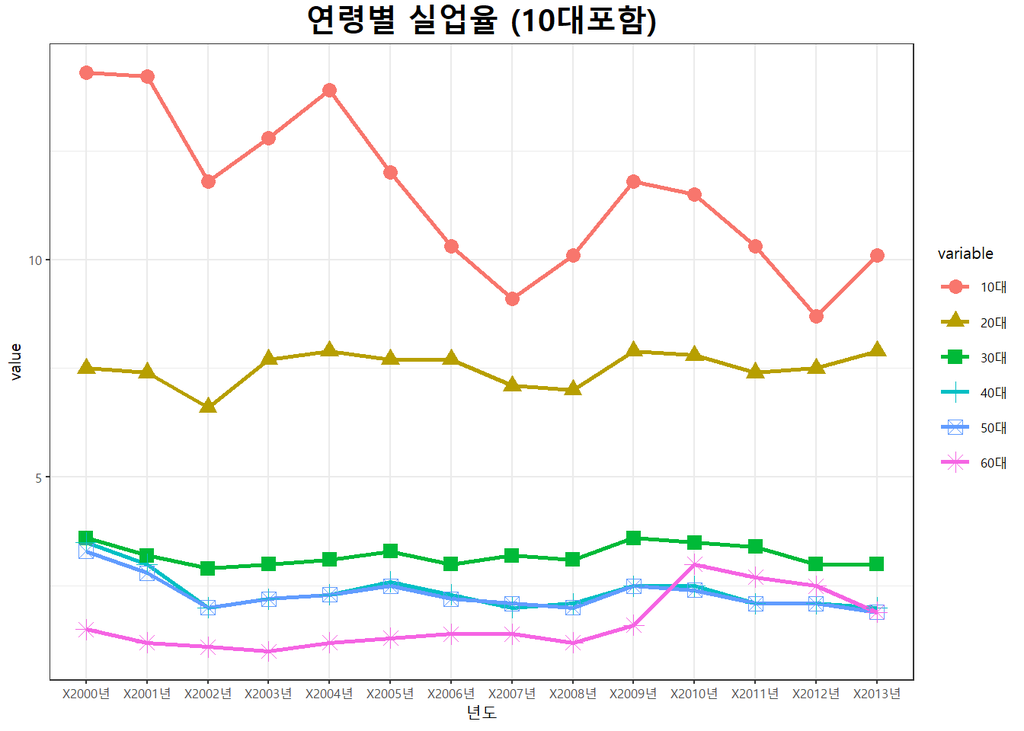

```r
count1 <- ggplot(mm7, aes(x=년도, y=value, group= variable,fill=variable,color=variable,shape=variable)) +
  geom_line(size=1) +
  geom_point(size=3) +
  theme_bw(base_family="malgun", base_size = 8) +
  ggtitle('연령별 실업율 (10대포함)') +
  theme(plot.title = element_text(family="malgun",
                                  face = "bold",
                                  hjust = 0.5,
                                  size = 15,
                                  color = "black"))


count1
```

```r
ggplotly(count1)
```

[interactive chart not shown]

# 학원에서 풀 당시에는 자료가 이어지질 않아서 그냥 제출하려고 했는데 group을 추가해 봄으로써 자료가 이어졌습니다.

# 그러나 이 자료를 전처리하는데 어려움이 많이 있었고, 일단은 풀어야겠다는 생각에 무식한 방법을 사용하였습니다.

# 전처리를 하는 방법에 대해서 여러각도를 제시해 주셨으면 합니다. array를 적용하기가 아직은 좀 어렵습니다.

## 3-6 콩나물 마을 버스 찾아달래요. : 버스 이용노선 바 그래프 입니다.

```r
data01 <- read.csv("data/버스노선별이용현황합계.csv")

df01 <- melt(data01,id.vars = 1)
df01
```

```
##    버스노선번호 variable  value
## 1       구로03  승차인원  96943
## 2       구로04  승차인원  87626
## 3       구로05  승차인원  40683
## 4       금천06  승차인원 216534
## 5       금천07  승차인원  13791
## 6       도봉04  승차인원  17501
## 7       도봉05  승차인원 240926
## 8       도봉06  승차인원 162291
## 9       동작10  승차인원  42827
## 10      동작11  승차인원 158472
## 11      마포08  승차인원 115599
## 12      마포09  승차인원 301508
## 13    서대문08  승차인원   2604
## 14    서대문09  승차인원 123557
```

[output cut: 34 more lines]

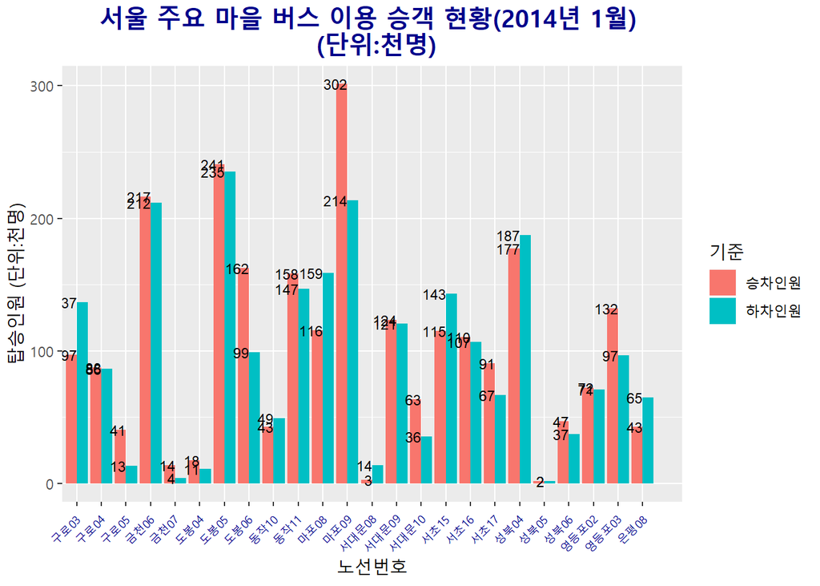

```r
colnames(df01) <- c("노선번호","기준","인원")
ggplot(df01,aes(x=노선번호,y=인원/1000,fill=기준)) +
  geom_bar(stat = "identity" ,position="dodge") +
  labs(y="탑승인원 (단위:천명)") +
  theme(axis.text.x = element_text(angle = 45,hjust = 1,vjust = 1,color = "darkblue",size=7)) +
  geom_text(aes(label=round(인원/1000)), size=3, hjust=1, color='black') +
  ggtitle(paste('서울 주요 마을 버스 이용 승객 현황(2014년 1월)', '\n', '(단위:천명)')) +
  theme(plot.title = element_text(face = "bold", hjust = 0.5,
                                  size = 15, color = "darkblue")) +
  coord_cartesian(xlim = c(1,25), ylim = c(1,300))
```

# 코드를 작동하는데 걸린 시간보다 이 그래프를 꾸미는데 시간이 더 오래 걸렸습니다. 그 와중에 더 배운게 많은

# 것 같습니다.

## 3-7 마포 9번 마을버스 이용 현황 분석 : 버스 이용 라인그래프 입니다.

```r
data001 <- read.csv("data/마포09번이용현황.csv")
data001
```

```
##                    정류소명 승차인원 하차인원
## 1   망원유수지.망원한강공원    14914      557
## 2                  태양식당    13723      111
## 3     신태양목욕탕.망원교회    10377      116
## 4                성원아파트    16320      211
## 5              동교초등학교    11993      593
## 6        하나은행망원동지점    13009     1268
## 7                  망원시장    13638     3120
## 8                망원우체국     9014    12428
## 9                망원전철역    19176    25257
## 10             성산초등학교     4941     2020
## 11                 고니빌딩     2604     2460
## 12           서교동주민센터     2818     4309
## 13       우리은행서교동지점     2580     4490
## 14         서교동예식장타운     4600    12701
```

[output cut: 18 more lines]

```r
df001 <- melt(data001, id.vars = 1)
colnames(df001) <- c("정류소명","기준","인원")
df001
```

```
##                    정류소명     기준  인원
## 1   망원유수지.망원한강공원 승차인원 14914
## 2                  태양식당 승차인원 13723
## 3     신태양목욕탕.망원교회 승차인원 10377
## 4                성원아파트 승차인원 16320
## 5              동교초등학교 승차인원 11993
## 6        하나은행망원동지점 승차인원 13009
## 7                  망원시장 승차인원 13638
## 8                망원우체국 승차인원  9014
## 9                망원전철역 승차인원 19176
## 10             성산초등학교 승차인원  4941
## 11                 고니빌딩 승차인원  2604
## 12           서교동주민센터 승차인원  2818
## 13       우리은행서교동지점 승차인원  2580
## 14         서교동예식장타운 승차인원  4600
```

[output cut: 50 more lines]

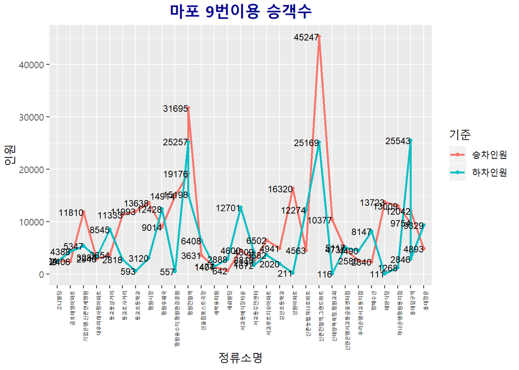

```r
ggplot(df001,aes(x=정류소명,y=인원,group=기준,fill=기준,color=기준)) +
  geom_point() +
  geom_line(size=1) +
  theme(axis.text.x = element_text(angle = 90,hjust = 1,vjust = 1,color = "black",size=5)) +
  geom_text(aes(label=인원), size=3, hjust=1, color='black') +
  ggtitle(paste('마포 9번이용 승객수')) +
  theme(plot.title = element_text(face = "bold", hjust = 0.5,
                                  size = 15, color = "darkblue"))
```

# 이 예제를 풀면서 group에 대해 알게 되어 요긴하게 적용하였습니다. 그러나 책에서와 같이 데이터의 순서대로가 아닌

# 가나다라 순의 그래프 인지라 조금 다르게 작성되었습니다. 이 문제에 대해서는 이 후에 조금더 공부해 보겠습니다.

# 수업시간에 이야기 해 주셔도 좋을것 같습니다. 감사합니다.